# action items

Kianté Fernandez

6/5/2020

```r
load("clean_task_data.2020.27.12.RData")
Neuroethics_Judgement %>%
dplyr::select(user_id, condition, Risk_Beta, Gain_Beta) %>%
  distinct() -> data.h
```

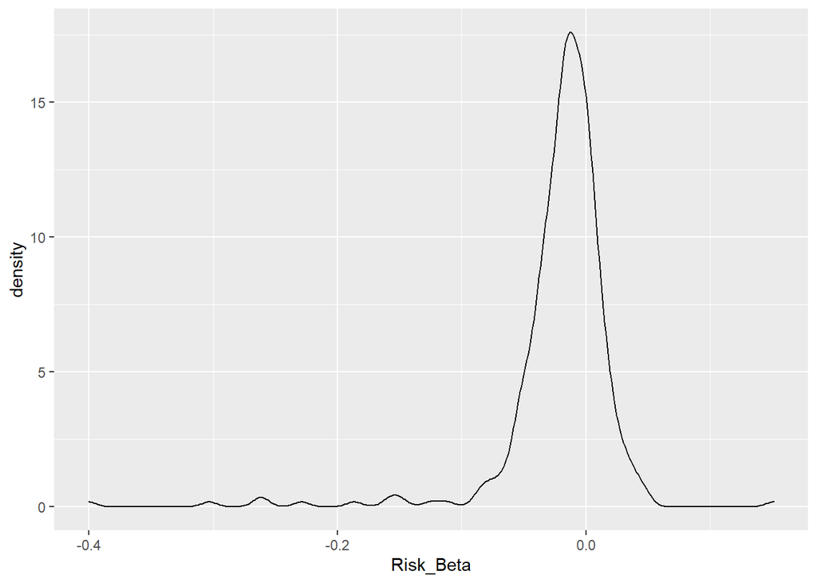

```r
ggplot(data.h, aes(Risk_Beta)) + geom_density()
```

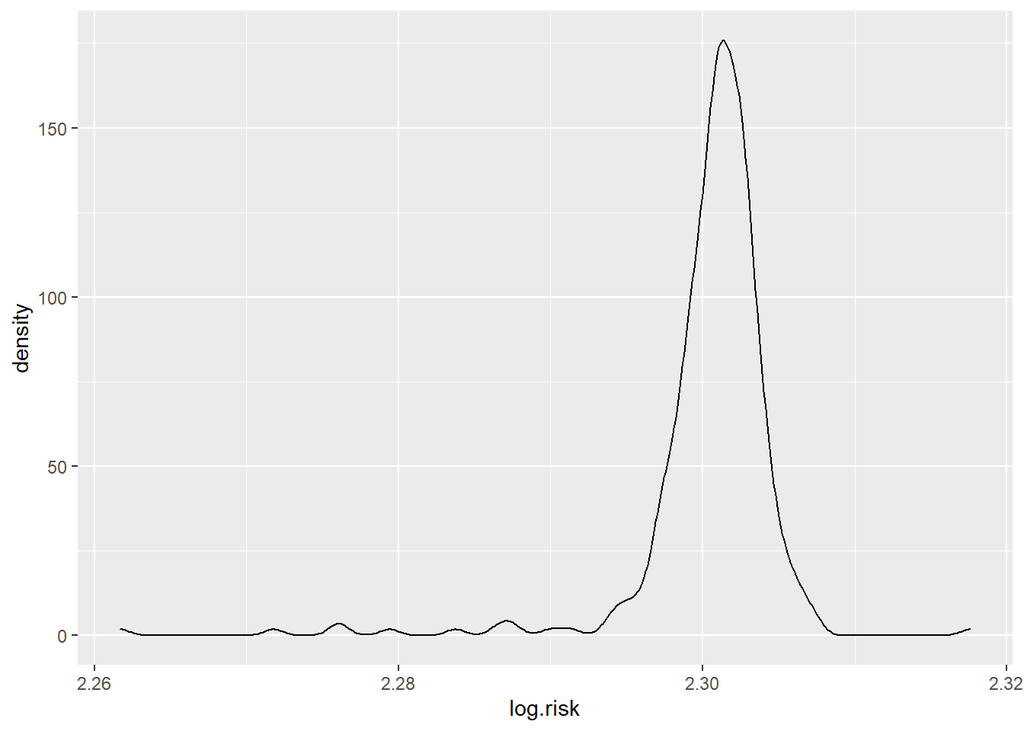

```r
ggplot(data.h, aes(log.risk)) + geom_density()
```

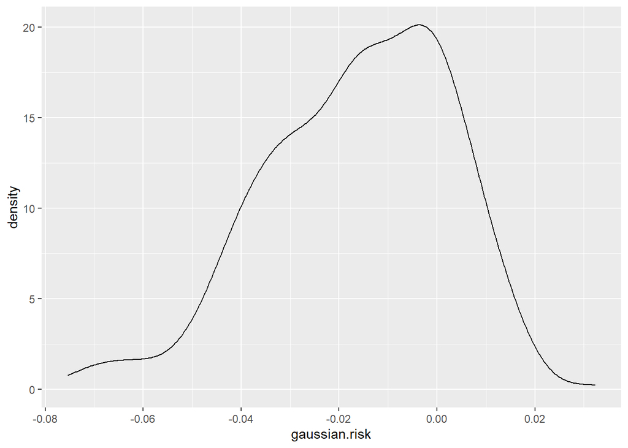

```r
ggplot(data.h, aes(gaussian.risk)) + geom_density()
```

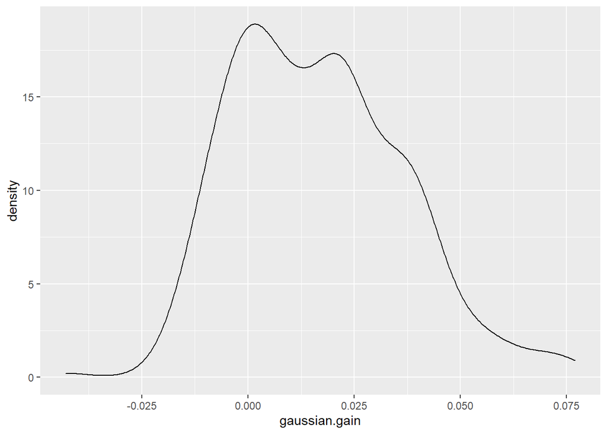

```r
ggplot(data.h, aes(gaussian.gain)) + geom_density()
```

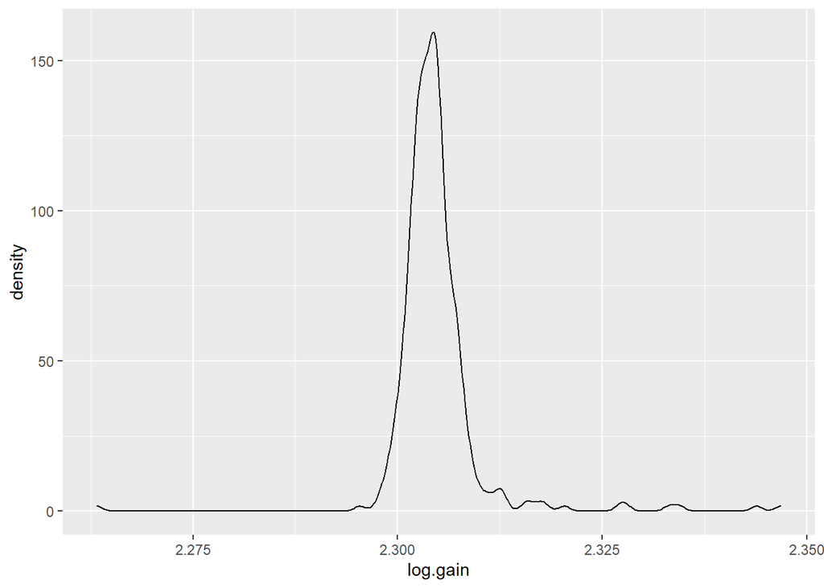

```r
ggplot(data.h, aes(log.gain)) + geom_density()
```

[figure not shown]

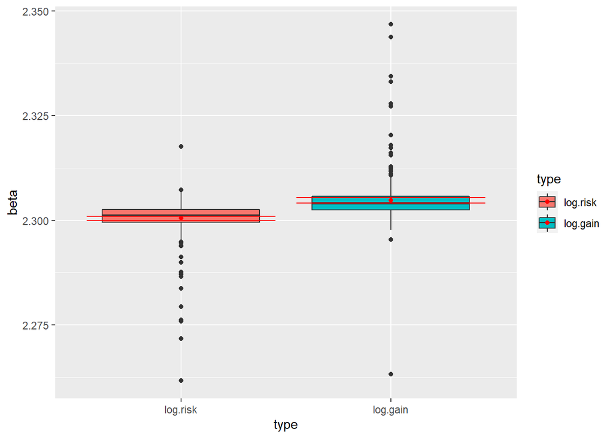

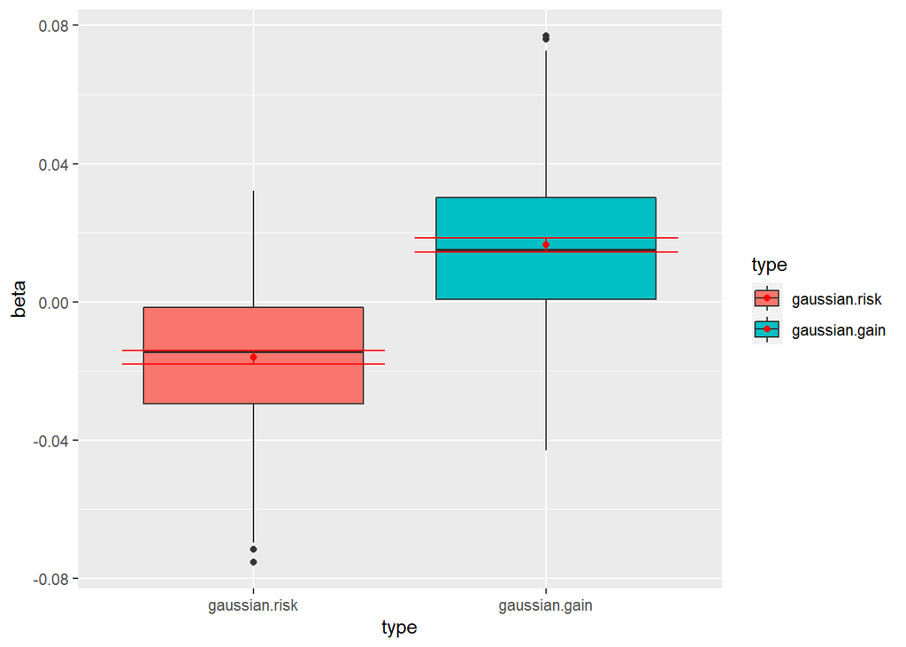

Transformed data test

| method | estimate | statistic | conf.low | conf.high | p.value |
| --- | --- | --- | --- | --- | --- |
| One Sample t-test | -0.0161012 | -15.71373 | -0.0181167 | -0.0140857 | 0 |
| One Sample t-test | 0.0165003 | 15.25762 | 0.0143731 | 0.0186275 | 0 |
| Paired t-test | -0.0326016 | -21.38327 | -0.0356005 | -0.0296026 | 0 |

Raw data test

| method | estimate | statistic | conf.low | conf.high | p.value |
| --- | --- | --- | --- | --- | --- |
| One Sample t-test | -0.0204104 | -8.228581 | -0.0252895 | -0.0155314 | 0.000000 |
| One Sample t-test | 0.0214129 | 6.873734 | 0.0152853 | 0.0275405 | 0.000000 |
| Paired t-test | -0.0035293 | -2.130679 | -0.0067875 | -0.0002711 | 0.033837 |

```
## [1] -0.4469152
```

```
## [1] 0.37333
```

```
## [1] -0.5466321
```

```r
ggplot(data.h, aes(Gain_Beta)) + geom_density()
```

[output not shown]

use the Mann-Whitney U Test for positive & negative betas against 0 use the dependent 2-group Wilcoxon Signed Rank Test to compare the ABSOLUTE VALUE OF risk and benefit betas. These are nonparametric alternatives to the one-sample and dependent samples t-test.

Nonparametric tests

| method | estimate | statistic | conf.low | conf.high | p.value |
| --- | --- | --- | --- | --- | --- |
| Wilcoxon signed rank test with continuity correction | -0.0151328 | 10254 | -0.0177242 | -0.0124592 | 0.0000000 |
| Wilcoxon signed rank test with continuity correction | 0.0154510 | 46423 | 0.0124360 | 0.0183515 | 0.0000000 |
| Wilcoxon signed rank test with continuity correction | -0.0021443 | 25607 | -0.0046875 | 0.0002552 | 0.0756958 |

Here, we want to test the effects of condition on risk and gain removing the effects of negative values and then logging the data. Investigate function log1p(). If the minimum value in the sample is lower than -1, just find that min and add the constant to all data elements.

## H2

one way anova for effect of condition on risk and gain

```
##              Df  Sum Sq   Mean Sq F value Pr(>F)
## condition     6 0.00182 0.0003028   0.848  0.533
## Residuals   332 0.11849 0.0003569
```

```
##              Df  Sum Sq   Mean Sq F value Pr(>F)
## condition     6 0.00242 0.0004027   1.016  0.415
## Residuals   332 0.13159 0.0003964
```

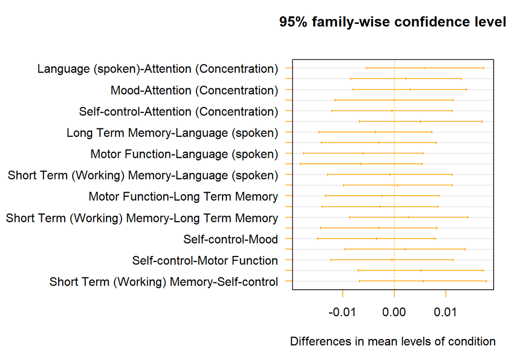

|  | diff | lwr | upr | p adj |
| --- | --- | --- | --- | --- |
| Language (spoken)-Attention (Concentration) | 0.0059771 | -0.0054087 | 0.0173630 | 0.7096015 |
| Long Term Memory-Attention (Concentration) | 0.0022973 | -0.0084751 | 0.0130698 | 0.9956973 |
| Mood-Attention (Concentration) | 0.0029902 | -0.0080086 | 0.0139891 | 0.9842236 |
| Motor Function-Attention (Concentration) | -0.0000245 | -0.0114739 | 0.0114249 | 1.0000000 |
| Self-control-Attention (Concentration) | -0.0004670 | -0.0121226 | 0.0111886 | 0.9999998 |
| Short Term (Working) Memory-Attention (Concentration) | 0.0051023 | -0.0067859 | 0.0169906 | 0.8637900 |
| Long Term Memory-Language (spoken) | -0.0036798 | -0.0146368 | 0.0072772 | 0.9545911 |
| Mood-Language (spoken) | -0.0029869 | -0.0141665 | 0.0081927 | 0.9855905 |
| Motor Function-Language (spoken) | -0.0060016 | -0.0176248 | 0.0056216 | 0.7254760 |
| Self-control-Language (spoken) | -0.0064441 | -0.0182705 | 0.0053822 | 0.6718112 |
| Short Term (Working) Memory-Language (spoken) | -0.0008748 | -0.0129305 | 0.0111809 | 0.9999916 |
| Mood-Long Term Memory | 0.0006929 | -0.0098614 | 0.0112472 | 0.9999954 |
| Motor Function-Long Term Memory | -0.0023218 | -0.0133449 | 0.0087012 | 0.9959806 |
| Self-control-Long Term Memory | -0.0027643 | -0.0140014 | 0.0084727 | 0.9906766 |
| Short Term (Working) Memory-Long Term Memory | 0.0028050 | -0.0086732 | 0.0142832 | 0.9910011 |
| Motor Function-Mood | -0.0030147 | -0.0142591 | 0.0082297 | 0.9853252 |
| Self-control-Mood | -0.0034573 | -0.0149115 | 0.0079970 | 0.9731043 |
| Short Term (Working) Memory-Mood | 0.0021121 | -0.0095789 | 0.0138030 | 0.9982909 |
| Self-control-Motor Function | -0.0004425 | -0.0123301 | 0.0114451 | 0.9999998 |
| Short Term (Working) Memory-Motor Function | 0.0051268 | -0.0069890 | 0.0172426 | 0.8715597 |
| Short Term (Working) Memory-Self-control | 0.0055693 | -0.0067415 | 0.0178802 | 0.8315662 |

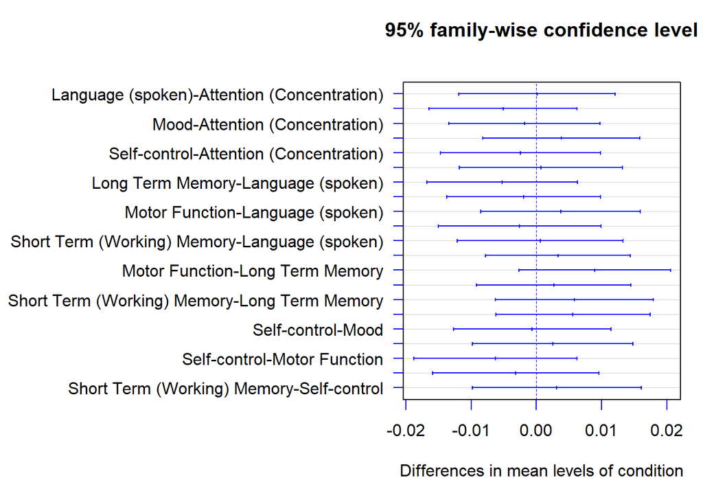

|  | diff | lwr | upr | p adj |
| --- | --- | --- | --- | --- |
| Language (spoken)-Attention (Concentration) | 0.0001245 | -0.0118744 | 0.0121234 | 1.0000000 |
| Long Term Memory-Attention (Concentration) | -0.0051139 | -0.0164664 | 0.0062386 | 0.8343872 |
| Mood-Attention (Concentration) | -0.0017954 | -0.0133865 | 0.0097957 | 0.9992871 |
| Motor Function-Attention (Concentration) | 0.0038355 | -0.0082304 | 0.0159015 | 0.9652208 |
| Self-control-Attention (Concentration) | -0.0024307 | -0.0147140 | 0.0098525 | 0.9971542 |
| Short Term (Working) Memory-Attention (Concentration) | 0.0007111 | -0.0118174 | 0.0132395 | 0.9999981 |
| Long Term Memory-Language (spoken) | -0.0052384 | -0.0167854 | 0.0063086 | 0.8297025 |
| Mood-Language (spoken) | -0.0019199 | -0.0137015 | 0.0098617 | 0.9990473 |
| Motor Function-Language (spoken) | 0.0037110 | -0.0085381 | 0.0159601 | 0.9725946 |
| Self-control-Language (spoken) | -0.0025552 | -0.0150184 | 0.0099079 | 0.9965369 |
| Short Term (Working) Memory-Language (spoken) | 0.0005866 | -0.0121183 | 0.0132915 | 0.9999994 |
| Mood-Long Term Memory | 0.0033185 | -0.0078041 | 0.0144411 | 0.9746231 |
| Motor Function-Long Term Memory | 0.0089494 | -0.0026672 | 0.0205661 | 0.2541663 |
| Self-control-Long Term Memory | 0.0026832 | -0.0091590 | 0.0145253 | 0.9940107 |
| Short Term (Working) Memory-Long Term Memory | 0.0058250 | -0.0062713 | 0.0179212 | 0.7860667 |
| Motor Function-Mood | 0.0056309 | -0.0062190 | 0.0174808 | 0.7964397 |
| Self-control-Mood | -0.0006354 | -0.0127064 | 0.0114357 | 0.9999988 |
| Short Term (Working) Memory-Mood | 0.0025064 | -0.0098140 | 0.0148269 | 0.9966824 |
| Self-control-Motor Function | -0.0062663 | -0.0187940 | 0.0062615 | 0.7543659 |
| Short Term (Working) Memory-Motor Function | -0.0031245 | -0.0158927 | 0.0096437 | 0.9909355 |
| Short Term (Working) Memory-Self-control | 0.0031418 | -0.0098319 | 0.0161155 | 0.9914273 |

Looks like the effect sizes for motor trend in differences acorss many other of the conditions. Motor is fairly different from the cog domains we consider and is sometimes thought of as it's own thing ( motor skills vs. cognitive skills). So we may see peoples intuitions about motor cognition is different than that of others when considering treatments

Another way to look at the graphs

[figure not shown]